# Machine Learning Assignment

## Getting and cleaning the data

After loading the data, a simple summary revealed that certain columns contained no information which could be used to create the model, thus the following columns were removed from both the testing and the training dataset:

```r
t <- read.csv(file="C:\\Users\\minxi_000\\Documents\\R\\Exp Data Assignment2\\pml-training.csv", header=TRUE, na.strings = c("", " ","NA"))
t <- t[, !apply(t, 2, function(x) any(is.na(x)))]
t<-t[,-(1:7)]

testing<-read.csv(file="C:\\Users\\minxi_000\\Documents\\R\\Exp Data Assignment2\\pml-testing.csv", header=TRUE, na.strings = c("", " ","NA"))
testing <- testing[, !apply(testing, 2, function(x) any(is.na(x)))]
testing<-testing[,-(1:7)]
```

The next step was to split the original training dataset into a new training and a validation datasetusing the following:

```r
library(caret)
library(e1071)
library(randomForest)
inTrain<-createDataPartition(y=t$classe, p=0.7, list=FALSE)
training<-t[inTrain,]
vali<-t[-inTrain,]
```

## Fitting the model

In order to fit the model we needed was to separate the predictors from the predicted values and deal with the missing values using na.roughfix() from the randomForest package as follows:

```r
classe<-training[,53]
predictors<-training[,-53]
predictors[] <- lapply(predictors, function(x) as.numeric(as.character(x)))
fp<-na.roughfix(predictors)


vclasse<-vali[,53]
vpredictors<-vali[,-53]
vpredictors[] <- lapply(vpredictors, function(x) as.numeric(as.character(x)))
vfp<-na.roughfix(vpredictors)
```

Then the model was fitted using the randomForest package:

```r
rfmodel<-randomForest(fp,classe)
```

## Cross-validation

In order to acrtain the most relevant predictors at the model and plot the error rate vs. number of trees, I used the following comands:

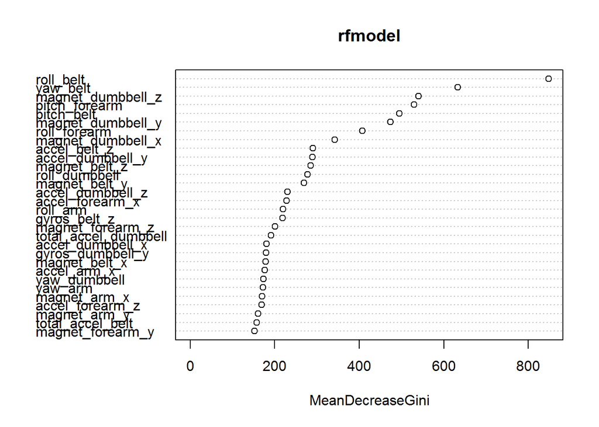

```r
varImpPlot(rfmodel)
```

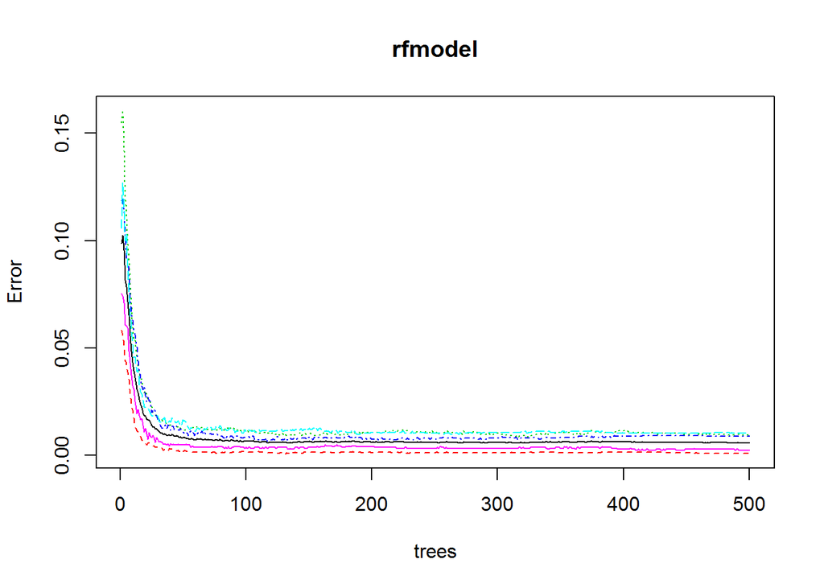

```r
plot(rfmodel)
```

In order to validate the model, I’ve applied it to the validation dataset and then created the confusion matrix using the following commands:

```r
pvalidate<-predict(rfmodel,newdata=vfp)
confusionMatrix(pvalidate,vclasse)
```

```
## Confusion Matrix and Statistics
##
##           Reference
## Prediction    A    B    C    D    E
##          A 1674    3    0    0    0
##          B    0 1134    0    0    0
##          C    0    2 1026    6    2
##          D    0    0    0  956    0
##          E    0    0    0    2 1080
##
## Overall Statistics
##
##                Accuracy : 0.9975
##                  95% CI : (0.9958, 0.9986)
##     No Information Rate : 0.2845
##     P-Value [Acc > NIR] : < 2.2e-16
##
##                   Kappa : 0.9968
##  Mcnemar's Test P-Value : NA
##
## Statistics by Class:
##
##                      Class: A Class: B Class: C Class: D Class: E
## Sensitivity            1.0000   0.9956   1.0000   0.9917   0.9982
## Specificity            0.9993   1.0000   0.9979   1.0000   0.9996
## Pos Pred Value         0.9982   1.0000   0.9903   1.0000   0.9982
## Neg Pred Value         1.0000   0.9989   1.0000   0.9984   0.9996
## Prevalence             0.2845   0.1935   0.1743   0.1638   0.1839
## Detection Rate         0.2845   0.1927   0.1743   0.1624   0.1835
## Detection Prevalence   0.2850   0.1927   0.1760   0.1624   0.1839
## Balanced Accuracy      0.9996   0.9978   0.9990   0.9959   0.9989
```

Reviewing the confusion matrix showed that the model accuracy is over 99%, hence I decided that the model is accurate enough for the purposes of the assignment.

```r
tclasse<-testing[,53]
tpredictors<-testing[,-53]
tfp<-na.roughfix(tpredictors)
tvalidate<-predict(rfmodel,newdata=tfp)
```